# Emotion Ratings Analysis V4

Leonardo Cerliani

2024-11-27

# Version notes

Now we estimate congruence only with the LOO correlation method between each subject’s ratings for each movie (vector of length 6) and the mean of all other subs.

Once obtained the congruence (r) scores, we detect outliers in the following way:

- Transfom all the r values to Z scores (Fisher) and average them per sub across movies. This will yield 26 Z scores. At this point, detect the outlier(s) as those who lie > 2 std from the mean.
- Repeat this with R^2 scores. This the conversion to Z scores will be achieved with the `scale` function on the R^2 scores.
- Ascertain the quality of being an outlier with boxplot (1.5 IQR)

Also, congruence will be plot as R^2

NB: A lot of previous stuff is not present anymore - e.g. the initial calculation of congruence using % of correctly detected emotion in movies. These can be found in previous V1..V3 of this notebook.

```r
library(tidyverse)
library(RColorBrewer)

bd <- "/data00/leonardo/RSA/analyses/RATINGS"

subs_file <- "/data00/leonardo/RSA/sub_list.txt"
subs <- sprintf("%02d",readLines(subs_file) %>% as.numeric)

# Load the preprocessed emotion ratings file
# which was prepared with the 02_prepare_ratings_EMOTION.Rmd
# located in /data00/leonardo/RSA/prep_scripts/05_prepare_ratings
df <- read_csv(paste0(bd,"/","emotion_ratings.csv"))
```

# Emotion

## Examine congruence

We need to do the following for each movie, but let’s explain the procedure for one movie only since it’s simpler:

- given one movie ratings (vector of 6), for each subject take the mean of the ratings of all other subs (also a vector of 6)
- then correlate the ratings of that sub with the mean of all other sub for that movie
- repeat for each sub
- now apply to each movie

## Building and testing the fn on one sub across movies

```r
# Let's start with only one movie
df_one_movie <- df %>%
  select(sub, video, starts_with("r_"), emotion) %>%
  filter(video == "AK_A_32.mp4")

df_one_movie
```

```
## # A tibble: 26 × 9
##    sub   video       r_happy r_disgust r_sad r_fear r_anger r_pain emotion
##    <chr> <chr>         <dbl>     <dbl> <dbl>  <dbl>   <dbl>  <dbl> <chr>
##  1 02    AK_A_32.mp4       0         0     0      0       0      8 anger
##  2 03    AK_A_32.mp4       0         0     0      0       9      0 anger
##  3 05    AK_A_32.mp4       0         0     0      0       7      6 anger
##  4 07    AK_A_32.mp4       0         6     3      2       1      5 anger
##  5 09    AK_A_32.mp4       0         0     0      0       8      6 anger
##  6 10    AK_A_32.mp4       0         0     0      0       9      4 anger
##  7 11    AK_A_32.mp4       0         0     0      0       9      0 anger
##  8 12    AK_A_32.mp4       0         0     0      0       7      0 anger
##  9 14    AK_A_32.mp4       0         1     1      0       9      0 anger
## 10 15    AK_A_32.mp4       0         1     1      0       8      0 anger
## # ℹ 16 more rows
```

```r
# Get the name of the columns with ratings
rating_cols <- df_one_movie %>% select(starts_with("r_")) %>% colnames

# Function to calculate correlation for one subject
calculate_correlation <- function(sub_id, data, rating_cols) {
  # Separate the target subject
  target <- data %>% filter(sub == sub_id) %>% select(starts_with("r_"))

  # Calculate the mean ratings excluding the target subject
  others_mean <- data %>%
    filter(sub != sub_id) %>%
    summarise(across(all_of(rating_cols), mean, na.rm = TRUE))

  # Calculate the correlation
  corr <- cor(
    unlist(target),
    unlist(others_mean),
    use = "complete.obs"
  )

  # Return as a tibble
  tibble(
    sub = sub_id,
    # movie = unique(data$video),
    corr = corr
  )
}


# # Try the function with one sub (and one movie)
# sub_id = "03"
# data = df_one_movie
# calculate_correlation(sub_id = "03", data = df_one_movie, rating_cols)


# Map the function to all subjects
unique(df$sub) %>% map_dfr( ~ calculate_correlation(.x, df_one_movie, rating_cols))
```

```
## # A tibble: 26 × 2
##    sub      corr
##    <chr>   <dbl>
##  1 02     0.0360
##  2 03     0.939
##  3 05     0.848
##  4 07    -0.149
##  5 09     0.885
##  6 10     0.969
##  7 11     0.939
##  8 12     0.941
##  9 14     0.934
## 10 15     0.932
## # ℹ 16 more rows
```

## Carry out the calculation for each sub across movies

```r
# Now use the full dataset of ratings with all movies.
# We will therefore need to write two nested loops
#
# NB: in the loop below, x = nested_df for each row of 'data'

congruence <- df %>%

  # Remove neutral first!
  filter(emotion != "neutral") %>%

  select(sub, video, starts_with("r_")) %>%
  group_by(video) %>%
  nest() %>%
  mutate(
    correlations = map(data, function(x) {
      # Extract the column names for ratings
      rating_cols <- x %>% select(starts_with("r_")) %>% colnames()

      # Iterate over the subjects in the nested data and calculate correlation
      map_dfr(x$sub, function(sub_id) {
        calculate_correlation(sub_id, x, rating_cols)
      })
    })
  ) %>%
  select(video, correlations) %>%
  unnest(correlations) %>%
  ungroup
  # NB: in some cases the rating was all zeros, thereby leading to no sd and
  # NA in the corr calculation. Replace these with zeros
  congruence <- congruence %>%
    mutate(corr = ifelse(is.na(corr), 0, corr))

  # congruence is the column named corr
  congruence
```

```
## # A tibble: 1,248 × 3
##    video       sub      corr
##    <chr>       <chr>   <dbl>
##  1 AK_A_32.mp4 02     0.0360
##  2 AK_A_32.mp4 03     0.939
##  3 AK_A_32.mp4 05     0.848
##  4 AK_A_32.mp4 07    -0.149
##  5 AK_A_32.mp4 09     0.885
##  6 AK_A_32.mp4 10     0.969
##  7 AK_A_32.mp4 11     0.939
##  8 AK_A_32.mp4 12     0.941
##  9 AK_A_32.mp4 14     0.934
## 10 AK_A_32.mp4 15     0.932
## # ℹ 1,238 more rows
```

## Visualization of congruence (R)

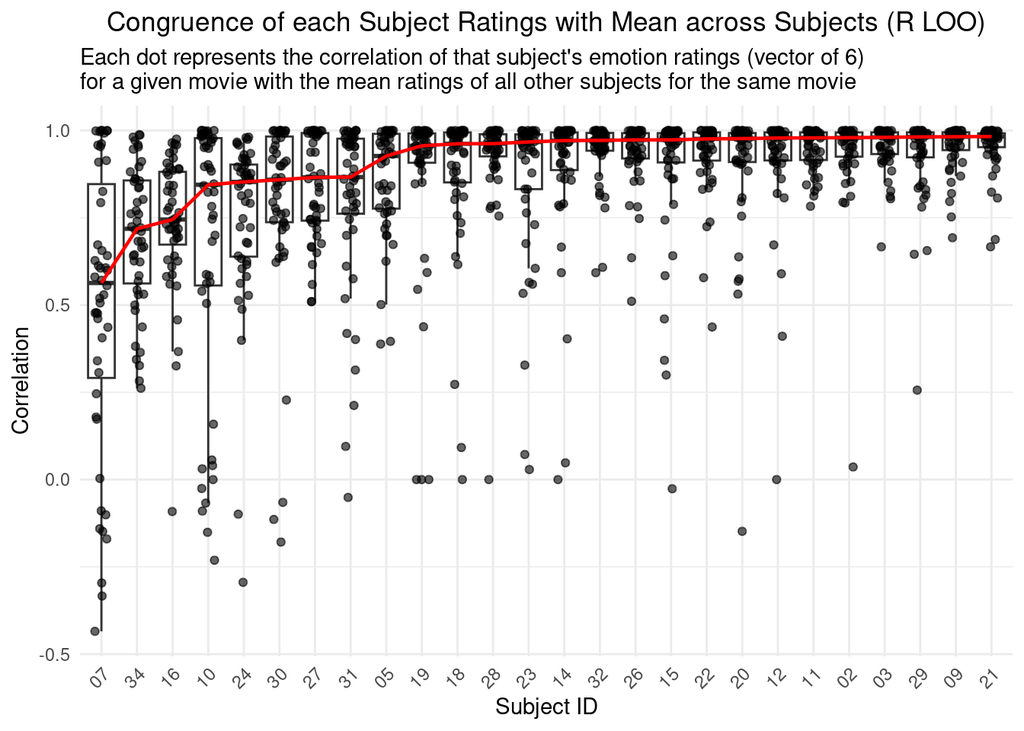

```r
# Calculate the median correlation for each subject
median_corrs <- congruence %>%
  group_by(sub) %>%
  summarise(median_corr = median(corr, na.rm = TRUE)) %>%
  arrange(median_corr)

# Create the plot
congruence %>%
  ggplot(aes(x = sub, y = corr)) +
  geom_boxplot(outlier.shape = NA) +  # Boxplot for each subject
  geom_jitter(width = 0.2, alpha = 0.6) +  # Dots inside the boxplot
  scale_x_discrete(limits = median_corrs$sub) +  # Order subjects by their median correlation
  geom_line(data = median_corrs, aes(x = sub, y = median_corr, group = 1), color = "red", linewidth = 0.8) +  # Corrected geom_line
  labs(
    title = "Congruence of each Subject Ratings with Mean across Subjects (R LOO)",
    subtitle = ("Each dot represents the correlation of that subject's emotion ratings (vector of 6)
for a given movie with the mean ratings of all other subjects for the same movie"),
    x = "Subject ID",
    y = "Correlation"
  ) +
  theme_minimal() +  # Use a minimal theme for a cleaner look
  theme(
    axis.text.x = element_text(angle = 45, hjust = 1),  # Rotate x-axis labels for better readability
    plot.title = element_text(hjust = 0.5)  # Center the title
  )
```

## Same plot but with R^2

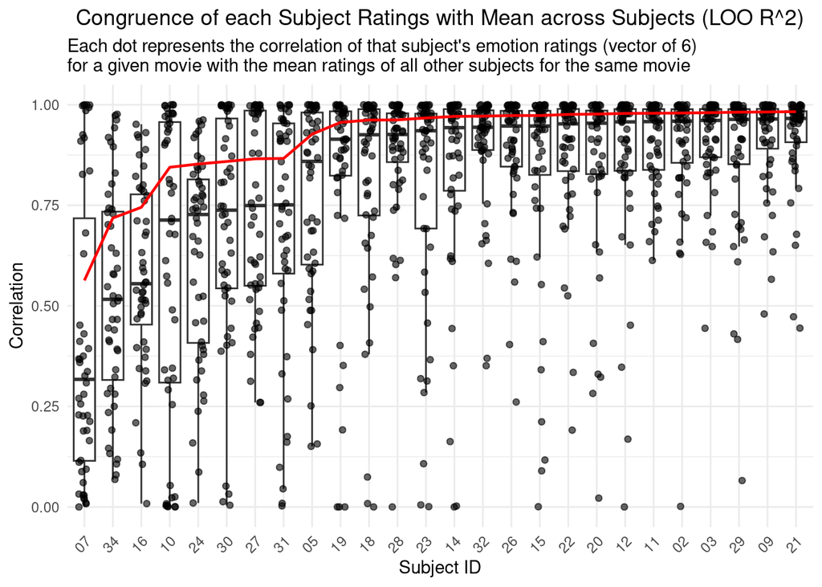

```r
congruence %>%
  mutate(corr = corr^2) %>%
  ggplot(aes(x = sub, y = corr)) +
  geom_boxplot(outlier.shape = NA) +  # Boxplot for each subject
  geom_jitter(width = 0.2, alpha = 0.6) +  # Dots inside the boxplot
  scale_x_discrete(limits = median_corrs$sub) +  # Order subjects by their median correlation
  geom_line(data = median_corrs, aes(x = sub, y = median_corr, group = 1), color = "red", linewidth = 0.8) +  # Corrected geom_line
  labs(
    title = "Congruence of each Subject Ratings with Mean across Subjects (LOO R^2)",
    subtitle = ("Each dot represents the correlation of that subject's emotion ratings (vector of 6)
for a given movie with the mean ratings of all other subjects for the same movie"),
    x = "Subject ID",
    y = "Correlation"
  ) +
  theme_minimal() +  # Use a minimal theme for a cleaner look
  theme(
    axis.text.x = element_text(angle = 45, hjust = 1),  # Rotate x-axis labels for better readability
    plot.title = element_text(hjust = 0.5)  # Center the title
  )
```

## Detecting Outliers

We detect as outliers those subjects whose congruence score (either R or R^2) across movies are < 2 std in the distribution of the mean congruence score per subject.

```r
# 1. r-to-Z Fisher transform of the congruence scores (R)
# Look for z_scaled values < 2
congruence %>%
  mutate(fisher_z = 0.5 * log((1 + corr) / (1 - corr))) %>%
  select(sub, fisher_z) %>%
  group_by(sub) %>%
  reframe(
    mean_z = mean(fisher_z)
  ) %>%
  mutate(z_scaled = scale(mean_z)) %>%
  arrange(z_scaled)
```

```
## # A tibble: 26 × 3
##    sub   mean_z z_scaled[,1]
##    <chr>  <dbl>        <dbl>
##  1 34      1.04      -2.09
##  2 07      1.07      -2.02
##  3 16      1.07      -2.02
##  4 24      1.18      -1.79
##  5 10      1.54      -1.05
##  6 31      1.70      -0.718
##  7 30      1.80      -0.512
##  8 27      1.98      -0.123
##  9 05      2.00      -0.0849
## 10 23      2.10       0.128
## # ℹ 16 more rows
```

```r
# 2. Z-scoring the R^2 values
# Look for z_scaled values < 2
mean_r2 <- congruence %>%
  mutate(r2 = corr^2) %>%
  group_by(sub) %>%
  reframe(
    mean_r2 = mean(r2)
  ) %>%
  mutate(z_scaled = scale(mean_r2)) %>%
  arrange(z_scaled)

mean_r2
```

```
## # A tibble: 26 × 3
##    sub   mean_r2 z_scaled[,1]
##    <chr>   <dbl>        <dbl>
##  1 07      0.410      -2.75
##  2 34      0.526      -1.89
##  3 16      0.576      -1.53
##  4 10      0.604      -1.32
##  5 24      0.628      -1.14
##  6 31      0.696      -0.641
##  7 30      0.698      -0.631
##  8 27      0.738      -0.333
##  9 05      0.770      -0.0977
## 10 23      0.795       0.0886
## # ℹ 16 more rows
```

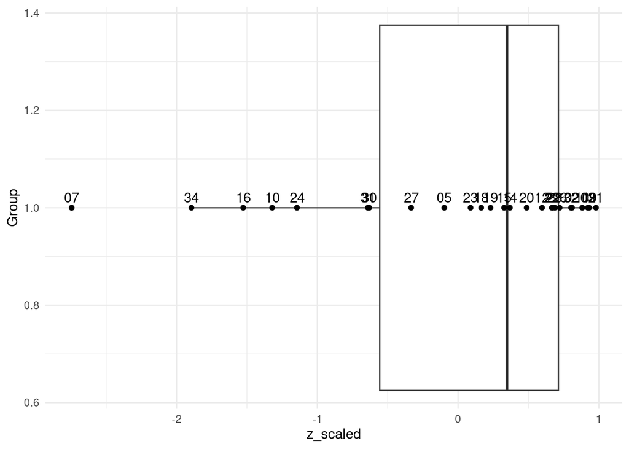

```r
# 3. sub(s) <> 1.5 IQR (efficiently with boxplot)
# boxplot(mean_r2$z_scaled)

is_outlier <- function(x) {
  return(x < quantile(x, 0.25) - 1.5 * IQR(x) | x > quantile(x, 0.75) + 1.5 * IQR(x))
}

mean_r2 %>%
  mutate(outlier = ifelse(is_outlier(z_scaled), z_scaled, as.numeric(NA))) %>%
  ggplot(aes(y = 1, x = z_scaled)) +  # Switch x and y aesthetics
  geom_boxplot() +
  geom_point() +
  geom_text(aes(label = sub), na.rm = TRUE, vjust = -0.5) +  # Use vjust for vertical adjustment
  theme_minimal() +
  labs(y = "Group", x = "z_scaled")  # Update axis labels
```

# Arousal and Valence

Here we should build a plot with paired intensity (high/low) bars. For each one of Arousal and Valence we will carry out a 6x2 RM ANOVA in JASP

References for plots: - [STHDA](https://www.sthda.com/english/articles/24-ggpubr-publication-ready-plots/77-facilitating-exploratory-data-visualization-application-to-tcga-genomic-data) - [ggpubr violin](https://rpkgs.datanovia.com/ggpubr/reference/ggviolin.html)

## Load ggpubr

```r
library(ggpubr)
```

## Arousal

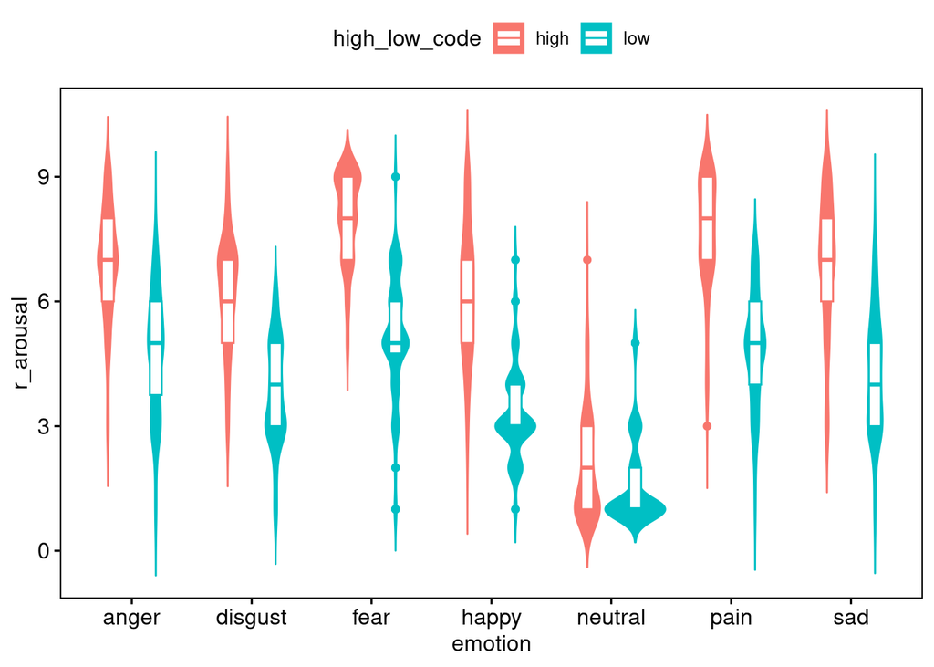

```r
df_A <- read_csv(paste0(bd,"/","arousal_ratings.csv")) %>%
  # filter(emotion != "neutral") %>%
  mutate(high_low_code = str_match(high_low_code, "high|low")) %>%
  select(sub, r_arousal, emotion, high_low_code, video)


# violin with boxplots
ggviolin(
  data = df_A,
  x = "emotion",
  y = "r_arousal",
  color = "high_low_code", fill = "high_low_code",
  add = c("boxplot"), add.params = list(fill = "white"),
  combine = TRUE
)
```

## Arousal (wide dataset)

In order to have different panels, we need to have a wide dataset. However, since for each combination of sub+emotion+high_low there are 4 movies (the 4 actors), we take an average of that within subject.

Check with `df_A %>% filter(sub=="02", emotion=="anger", high_low_code=="high")`

```r
df_A_wide <- df_A %>%
  group_by(sub,emotion,high_low_code) %>%
  reframe(
    r_arousal = mean(r_arousal)
  ) %>%
  ungroup() %>%
  pivot_wider(
    names_from = emotion,
    values_from = r_arousal
  ) %>%
  mutate(high_low_code = as.factor(high_low_code))
```

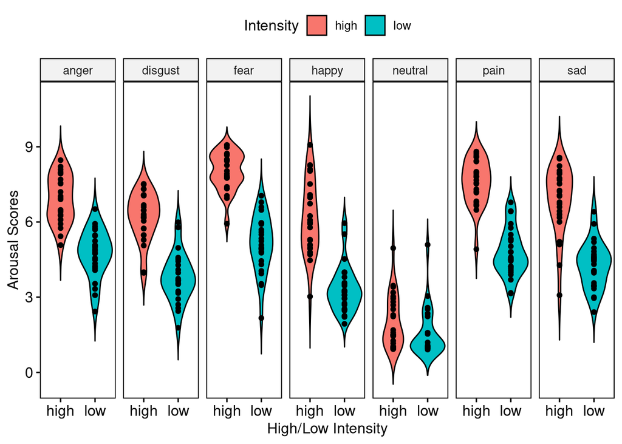

```r
# violin with jitter
ggviolin(
  data = df_A_wide,
  x = "high_low_code",                 # Grouping variable on the x-axis
  y = c("anger", "disgust", "fear", "happy", "neutral", "pain", "sad"), # Vector of y columns
  combine = TRUE,                      # Combine plots for multiple y columns
  color = "black",             # Color by high/low code
  fill = "high_low_code",              # Color palette
  ylab = "Arousal Scores",                     # Label for y-axis
  xlab = "High/Low Intensity",              # Label for x-axis
  legend.title = "Intensity",               # Title for the legend
  add = c("jitter"),                      # Add jittered points
  add.params = list(
    # size = 1,
    jitter = 0,
    color = "black",
    fill = "white"
  ), # Customize jittered points
  nrow = 1
)
```

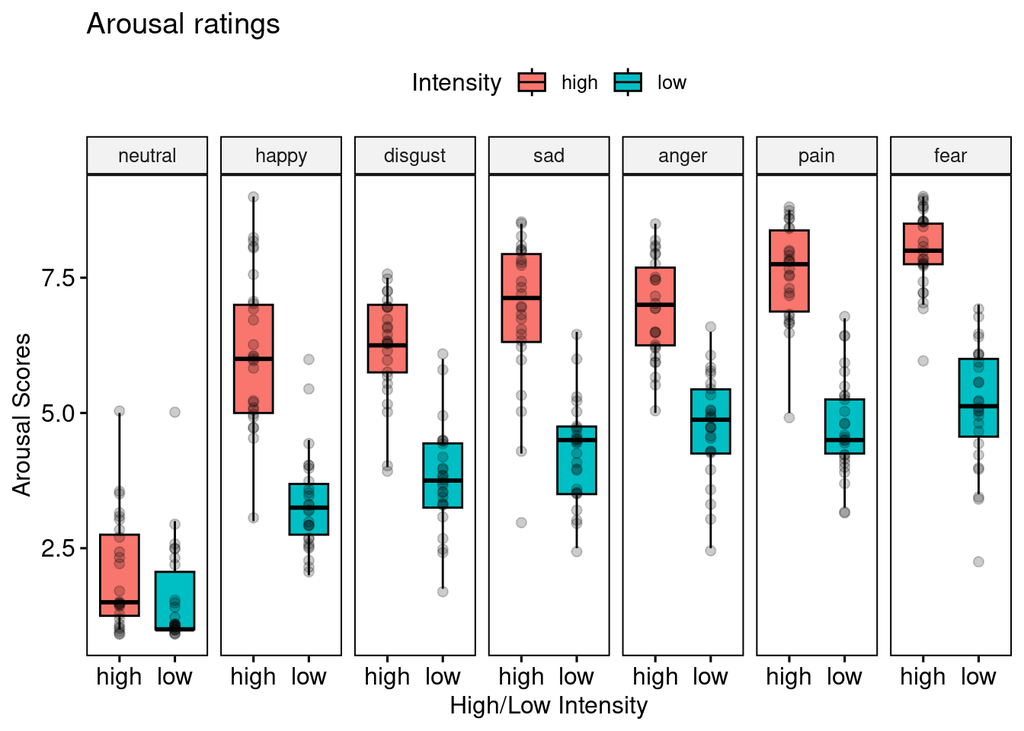

```r
# boxplot with jitter
ggboxplot(
  data = df_A_wide,
  x = "high_low_code",                 # Grouping variable on the x-axis
  y = c("neutral", "happy", "disgust", "sad", "anger", "pain", "fear"), # Vector of y columns
  combine = TRUE,                      # Combine plots for multiple y columns
  color = "black",             # Color by high/low code
  fill = "high_low_code",              # Color palette
  title = "Arousal ratings",
  ylab = "Arousal Scores",                     # Label for y-axis
  xlab = "High/Low Intensity",              # Label for x-axis
  legend.title = "Intensity",               # Title for the legend
  add = "jitter",                      # Add jittered points
  add.params = list(size = 2, jitter = 0, color = "black", alpha = 0.2), # Customize jittered points
  nrow = 1,  # all 6 facets on the same row
  # label = "sub",
  # label.select = list(top.up = 2, top.down = 2)
)
```

## Valence

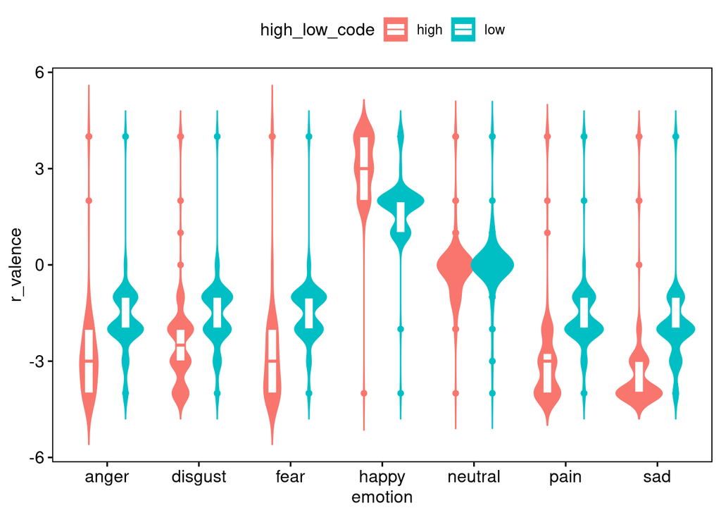

```r
df_V <- read_csv(paste0(bd,"/","valence_ratings.csv")) %>%
  # filter(emotion != "neutral") %>%
  mutate(r_valence = r_valence - 5) %>%   # REMOVE 5 FROM VALENCE
  mutate(high_low_code = str_match(high_low_code, "high|low")) %>%
  select(sub, r_valence, emotion, high_low_code, video)


# violin with boxplots
ggviolin(
  data = df_V,
  x = "emotion",
  y = "r_valence",
  color = "high_low_code", fill = "high_low_code",
  add = c("boxplot"), add.params = list(fill = "white"),
  combine = TRUE
)
```

## Valence (wide dataset)

In order to have different panels, we need to have a wide dataset. However, since for each combination of sub+emotion+high_low there are 4 movies (the 4 actors), we take an average of that within subject.

Check with `df_A %>% filter(sub=="02", emotion=="anger", high_low_code=="high")`

```r
df_V_wide <- df_V %>%
  group_by(sub,emotion,high_low_code) %>%
  reframe(
    r_valence = mean(r_valence)
  ) %>%
  ungroup() %>%
  pivot_wider(
    names_from = emotion,
    values_from = r_valence
  ) %>%
  mutate(high_low_code = as.factor(high_low_code))
```

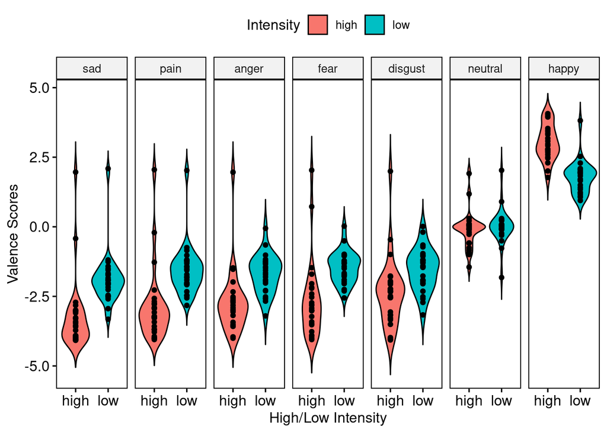

```r
# violin with jitter
ggviolin(
  data = df_V_wide,
  x = "high_low_code",                 # Grouping variable on the x-axis
  y = c("sad", "pain", "anger", "fear", "disgust", "neutral", "happy"), # Vector of y columns
  combine = TRUE,                      # Combine plots for multiple y columns
  color = "black",             # Color by high/low code
  fill = "high_low_code",              # Color palette
  ylab = "Valence Scores",                     # Label for y-axis
  xlab = "High/Low Intensity",              # Label for x-axis
  legend.title = "Intensity",               # Title for the legend
  add = c("jitter"),                      # Add jittered points
  add.params = list(
    # size = 1,
    jitter = 0,
    color = "black",
    fill = "white"
  ), # Customize jittered points
  nrow = 1
)
```

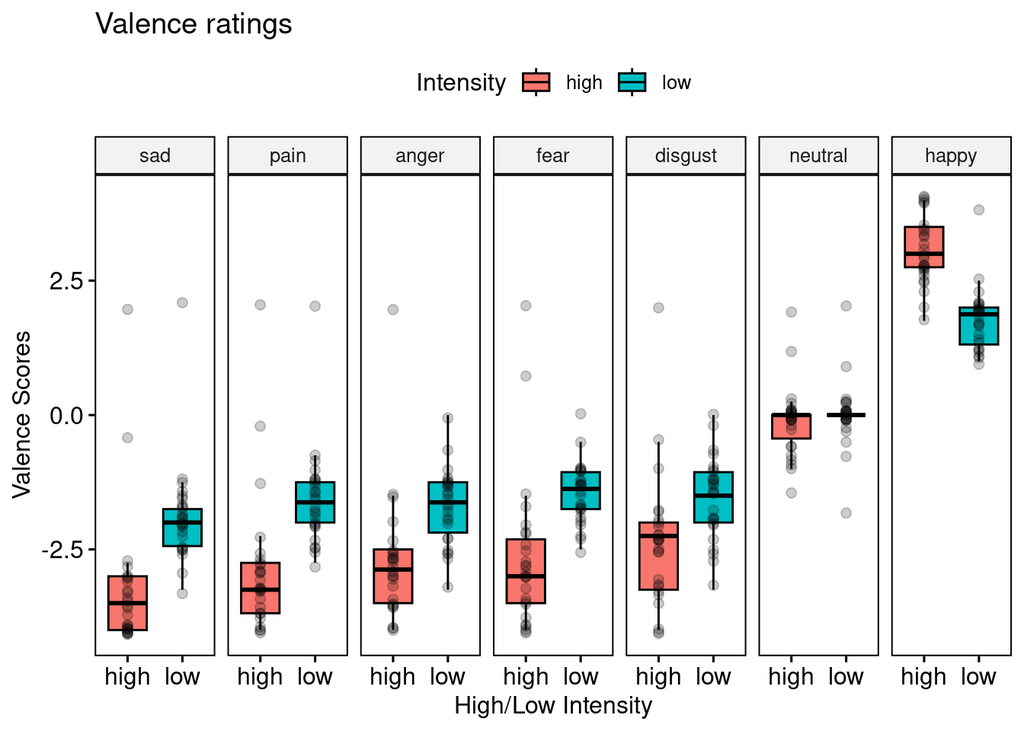

```r
# boxplot with jitter
ggboxplot(
  data = df_V_wide,
  x = "high_low_code",                 # Grouping variable on the x-axis
  y = c("sad", "pain", "anger", "fear", "disgust", "neutral", "happy"), # Vector of y columns
  combine = TRUE,                      # Combine plots for multiple y columns
  color = "black",             # Color by high/low code
  fill = "high_low_code",              # Color palette
  title = "Valence ratings",
  ylab = "Valence Scores",                     # Label for y-axis
  xlab = "High/Low Intensity",              # Label for x-axis
  legend.title = "Intensity",               # Title for the legend
  add = "jitter",                      # Add jittered points
  add.params = list(size = 2, jitter = 0, color = "black", alpha = 0.2), # Customize jittered points
  nrow = 1,
  # label = "sub",
  # label.select = list(top.up = 2, top.down = 2)
)
```

# Prepare data for JASP

We need two datasets - one for Arousal, one for Valence - with 14 columns each. For instance: sad_high, sad_low, pain_high, pain_low, usw

Again we start from df_A_wide to have only one score for each combination of sub+emotion+high/low_intensity

```r
# Arousal
df_A_for_JASP <- df_A_wide %>%
  pivot_longer(
    cols = -c(sub, high_low_code), # Keep 'sub' and 'high_low_code' as is
    names_to = "emotion",          # Name for the variable containing emotions
    values_to = "value"            # Name for the variable containing values
  ) %>%
  unite("new_column", emotion, high_low_code, sep = "_") %>% # Combine emotion and high_low_code
  pivot_wider(
    names_from = new_column,       # Create columns based on the new combined names
    values_from = value            # Populate the columns with values
  )

df_A_for_JASP %>% write_csv(
  paste0(bd,"/ANALYSES_OF_RATINGS/AROUSAL_Emotion_by_Intensity_4_JASP.csv")
)


# Valence
df_V_for_JASP <- df_V_wide %>%
  pivot_longer(
    cols = -c(sub, high_low_code), # Keep 'sub' and 'high_low_code' as is
    names_to = "emotion",          # Name for the variable containing emotions
    values_to = "value"            # Name for the variable containing values
  ) %>%
  unite("new_column", emotion, high_low_code, sep = "_") %>% # Combine emotion and high_low_code
  pivot_wider(
    names_from = new_column,       # Create columns based on the new combined names
    values_from = value            # Populate the columns with values
  )

df_V_for_JASP %>% write_csv(
  paste0(bd,"/ANALYSES_OF_RATINGS/VALENCE_Emotion_by_Intensity_4_JASP.csv")
)
```